# Principal Component Analysis

Joshua Zieve  
November 3, 2021

### Principal Component Analysis

Principal Component Analysis (PCA) attempts to find uncorrelated linear dimensions that capture maximal variance in the data

### What does that actually mean?

PCA allows you to summarize the data by means of a smaller set of “summary indices” that can more easily visualized and analyzed.

- When faced with a large set of correlated variables, principal components allow us to summarize this set with a smaller number of representative variables that collectively explain most of the variability in the original set.
  - In particular, we would like to find a low-dimensional representation of the data that captures as much of the information as possible.
  - [PCA Visual](https://en.wikipedia.org/wiki/Principal_component_analysis#/media/File:GaussianScatterPCA.svg)

### Put differently...

PCA is just a rotation of the data onto new axes that capture as much variance as possible, and is not inherently a dimensionality reduction technique

- (although you can reduce the dimension of the data by retaining only a subset of the PCs)

### 5 Basic Steps

To do a PCA, you must…

1. Standardize the range of continuous initial variables
2. Compute the covariance matrix to identify correlations
3. Compute the eigenvectors and eigenvalues of the covariance matrix to identify the principal components
4. Create a feature vector to decide which principal components to keep
5. Recast the data along the principal components axes

### Possible Use Cases

The following is a non-exhaustive list of PCA applications:

- image compression
- neuroscience: identify the specific properties of a stimulus
- At Josh's last job, we used PCA to reduce dozens of psychographic survey questions to fewer aggregate variables (for clustering)
- Any others folks have come across?

### Questions?

### Exercise

Lets use survey brand data for an example

- Data are ratings of 10 brands (a-j) on 9 adjectives. For each adjective, data are rated on a 1-10 scale.

### View Data

```
  perform leader latest fun serious bargain value trendy rebuy brand
1       2      4      8   8       2       9     7      4     6     a
2       1      1      4   7       1       1     1      2     2     a
3       2      3      5   9       2       9     5      1     6     a
4       1      6     10   8       3       4     5      2     1     a
5       1      1      5   8       1       9     9      1     1     a
6       2      8      9   5       3       8     7      1     2     a
```

### It's good practice to rescale raw data (Step 1)

- Before

```
    perform           leader           latest            fun
 Min.   : 1.000   Min.   : 1.000   Min.   : 1.000   Min.   : 1.000
 1st Qu.: 1.000   1st Qu.: 2.000   1st Qu.: 4.000   1st Qu.: 4.000
 Median : 4.000   Median : 4.000   Median : 7.000   Median : 6.000
 Mean   : 4.488   Mean   : 4.417   Mean   : 6.195   Mean   : 6.068
 3rd Qu.: 7.000   3rd Qu.: 6.000   3rd Qu.: 9.000   3rd Qu.: 8.000
 Max.   :10.000   Max.   :10.000   Max.   :10.000   Max.   :10.000
    serious          bargain           value            trendy
 Min.   : 1.000   Min.   : 1.000   Min.   : 1.000   Min.   : 1.00
 1st Qu.: 2.000   1st Qu.: 2.000   1st Qu.: 2.000   1st Qu.: 3.00
 Median : 4.000   Median : 4.000   Median : 4.000   Median : 5.00
 Mean   : 4.323   Mean   : 4.259   Mean   : 4.337   Mean   : 5.22
 3rd Qu.: 6.000   3rd Qu.: 6.000   3rd Qu.: 6.000   3rd Qu.: 7.00
 Max.   :10.000   Max.   :10.000   Max.   :10.000   Max.   :10.00
     rebuy
 Min.   : 1.000
 1st Qu.: 1.000
 Median : 3.000
 Mean   : 3.727
 3rd Qu.: 5.000
 Max.   :10.000
```

- After

```
    perform            leader            latest             fun
 Min.   :-1.0888   Min.   :-1.3100   Min.   :-1.6878   Min.   :-1.84677
 1st Qu.:-1.0888   1st Qu.:-0.9266   1st Qu.:-0.7131   1st Qu.:-0.75358
 Median :-0.1523   Median :-0.1599   Median : 0.2615   Median :-0.02478
 Mean   : 0.0000   Mean   : 0.0000   Mean   : 0.0000   Mean   : 0.00000
 3rd Qu.: 0.7842   3rd Qu.: 0.6069   3rd Qu.: 0.9113   3rd Qu.: 0.70402
 Max.   : 1.7206   Max.   : 2.1404   Max.   : 1.2362   Max.   : 1.43281
    serious           bargain             value             trendy
 Min.   :-1.1961   Min.   :-1.22196   Min.   :-1.3912   Min.   :-1.53897
 1st Qu.:-0.8362   1st Qu.:-0.84701   1st Qu.:-0.9743   1st Qu.:-0.80960
 Median :-0.1163   Median :-0.09711   Median :-0.1405   Median :-0.08023
 Mean   : 0.0000   Mean   : 0.00000   Mean   : 0.0000   Mean   : 0.00000
 3rd Qu.: 0.6036   3rd Qu.: 0.65279   3rd Qu.: 0.6933   3rd Qu.: 0.64914
 Max.   : 2.0434   Max.   : 2.15258   Max.   : 2.3610   Max.   : 1.74319
     rebuy            brand
 Min.   :-1.0717   Length:1000
 1st Qu.:-1.0717   Class :character
 Median :-0.2857   Mode  :character
 Mean   : 0.0000
 3rd Qu.: 0.5003
 Max.   : 2.4652
```

### Hierarchical Clustering

- hclust puts our items in a hierarchical clustering order
- Add rectangles around the clusters (we've identified 3 here)
  - The visualization of the data shows three general clusters: fun/latest/trendy, rebuy/bargain/value, and perform/leader/serious

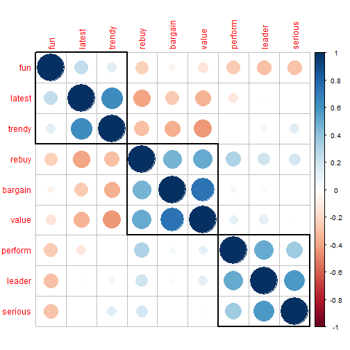

### Means

- Look at the average of position of the brand on each adjective

```
   brand     perform     leader     latest        fun     serious     bargain
1      a -0.88591874 -0.5279035  0.4109732  0.6566458 -0.91894067  0.21409609
2      b  0.93087022  1.0707584  0.7261069 -0.9722147  1.18314061  0.04161938
3      c  0.64992347  1.1627677 -0.1023372 -0.8446753  1.22273461 -0.60704302
4      d -0.67989112 -0.5930767  0.3524948  0.1865719 -0.69217505 -0.88075605
5      e -0.56439079  0.1928362  0.4564564  0.2958914  0.04211361  0.55155051
6      f -0.05868665  0.2695106 -1.2621589 -0.2179102  0.58923066  0.87400696
7      g  0.91838369 -0.1675336 -1.2849005 -0.5167168 -0.53379906  0.89650392
8      h -0.01498383 -0.2978802  0.5019396  0.7149495 -0.14145855 -0.73827529
9      i  0.33463879 -0.3208825  0.3557436  0.4124989 -0.14865746 -0.25459062
10     j -0.62994504 -0.7885965 -0.1543180  0.2849595 -0.60218870 -0.09711188
         value      trendy       rebuy
1   0.18469264 -0.52514473 -0.59616642
2   0.15133957  0.74030819  0.23697320
3  -0.44067747  0.02552787 -0.13243776
4  -0.93263529  0.73666135 -0.49398892
5   0.41816415  0.13857986  0.03654811
6   1.02268859 -0.81324496  1.35699580
7   1.25616009 -1.27639344  1.36092571
8  -0.78254646  0.86430070 -0.60402622
9  -0.80339213  0.59078782 -0.20317603
10 -0.07379367 -0.48138267 -0.96164748
```

### Change Row Labels to Brand names

- Name the rows with the brand labels and then dispense with the brand column because it is redundant
- Same matrix as before but now row names are brands instead of numbers

```
      perform     leader     latest        fun     serious     bargain
a -0.88591874 -0.5279035  0.4109732  0.6566458 -0.91894067  0.21409609
b  0.93087022  1.0707584  0.7261069 -0.9722147  1.18314061  0.04161938
c  0.64992347  1.1627677 -0.1023372 -0.8446753  1.22273461 -0.60704302
d -0.67989112 -0.5930767  0.3524948  0.1865719 -0.69217505 -0.88075605
e -0.56439079  0.1928362  0.4564564  0.2958914  0.04211361  0.55155051
f -0.05868665  0.2695106 -1.2621589 -0.2179102  0.58923066  0.87400696
g  0.91838369 -0.1675336 -1.2849005 -0.5167168 -0.53379906  0.89650392
h -0.01498383 -0.2978802  0.5019396  0.7149495 -0.14145855 -0.73827529
i  0.33463879 -0.3208825  0.3557436  0.4124989 -0.14865746 -0.25459062
j -0.62994504 -0.7885965 -0.1543180  0.2849595 -0.60218870 -0.09711188
        value      trendy       rebuy
a  0.18469264 -0.52514473 -0.59616642
b  0.15133957  0.74030819  0.23697320
c -0.44067747  0.02552787 -0.13243776
d -0.93263529  0.73666135 -0.49398892
e  0.41816415  0.13857986  0.03654811
f  1.02268859 -0.81324496  1.35699580
g  1.25616009 -1.27639344  1.36092571
h -0.78254646  0.86430070 -0.60402622
i -0.80339213  0.59078782 -0.20317603
j -0.07379367 -0.48138267 -0.96164748
```

### Covariance Matrix (Step 2)

```
            perform     leader     latest        fun
perform 10.26211812  4.1796837 -1.2073674 -2.2534374
leader   4.17968368  6.8039149  0.2159009 -2.0784344
latest  -1.20736737  0.2159009  9.4744494  2.0708108
fun     -2.25343744 -2.0784344  2.0708108  7.5309069
serious  3.19657257  4.1394484  0.0851001 -2.1431071
bargain  0.48809610  0.2302272 -2.0885936 -0.4870991
value    0.78332733  0.7402112 -2.5302452 -0.9558719
trendy   0.07671672  0.4757357  5.2973974  0.9630030
rebuy    2.49972372  1.3852262 -3.1108759 -1.6560921
            serious     bargain      value      trendy
perform  3.19657257  0.48809610  0.7833273  0.07671672
leader   4.13944845  0.23022723  0.7402112  0.47573574
latest   0.08510010 -2.08859359 -2.5302452  5.29739740
fun     -2.14310711 -0.48709910 -0.9558719  0.96300300
serious  7.71838939 -0.01967668  0.1583073  0.92186186
bargain -0.01967668  7.11303203  4.7314484 -2.56354354
value    0.15830731  4.73144845  5.7531842 -2.85799800
trendy   0.92186186 -2.56354354 -2.8579980  7.51911912
rebuy    1.27745646  3.17187888  3.0880891 -2.08102102
            rebuy
perform  2.499724
leader   1.385226
latest  -3.110876
fun     -1.656092
serious  1.277456
bargain  3.171879
value    3.088089
trendy  -2.081021
rebuy    6.474946
```

### Heat Map (Step 2)

- Use a heatmap to look at intensities of brands on adjectives
- Notice the groupings: fun/latest/trendy, rebuy/bargain/value, and perform/leader/serious

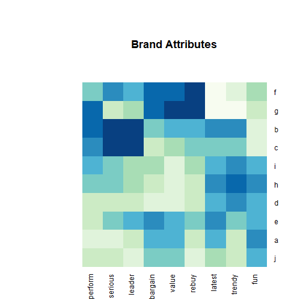

### PCA

- The first principal component direction of the data is that along which the observations vary the most
- The standard deviations of the principal components (i.e., the square roots of the eigenvalues of the covariance/correlation matrix, though the calculation is actually done with the singular values of the data matrix).

```r
set.seed(98286)

brand.pc <- prcomp(brand.sc[,1:9])
brand.pc1 <- prcomp(brand.ratings[,1:9], center = T)
summary(brand.pc)
```

```
Importance of components:
                         PC1    PC2    PC3    PC4     PC5
Standard deviation     1.726 1.4479 1.0389 0.8528 0.79846
Proportion of Variance 0.331 0.2329 0.1199 0.0808 0.07084
Cumulative Proportion  0.331 0.5640 0.6839 0.7647 0.83554
                           PC6     PC7     PC8     PC9
Standard deviation     0.73133 0.62458 0.55861 0.49310
Proportion of Variance 0.05943 0.04334 0.03467 0.02702
Cumulative Proportion  0.89497 0.93831 0.97298 1.00000
```

### PCA

- (you can copy and paste this to excel to conditionally format loadings and sort loadings to see how the factor structure is shaping up)

```r
brand.pc
```

```
Standard deviations (1, .., p=9):
[1] 1.7260636 1.4479474 1.0388719 0.8527667 0.7984647
[6] 0.7313298 0.6245834 0.5586112 0.4930993

Rotation (n x k) = (9 x 9):
               PC1         PC2         PC3         PC4
perform  0.2374679  0.41991179  0.03854006 -0.52630873
leader   0.2058257  0.52381901 -0.09512739 -0.08923461
latest  -0.3703806  0.20145317 -0.53273054  0.21410754
fun     -0.2510601 -0.25037973 -0.41781346 -0.75063952
serious  0.1597402  0.51047254 -0.04067075  0.09893394
bargain  0.3991731 -0.21849698 -0.48989756  0.16734345
value    0.4474562 -0.18980822 -0.36924507  0.15118500
trendy  -0.3510292  0.31849032 -0.37090530  0.16764432
rebuy    0.4390184  0.01509832 -0.12461593 -0.13031231
                PC5        PC6          PC7         PC8
perform  0.46793435 -0.3370676  0.364179109 -0.14444718
leader  -0.29452974 -0.2968860 -0.613674301  0.28766118
latest   0.10586676 -0.1742059 -0.185480310 -0.64290436
fun     -0.33149429  0.1405367 -0.007114761  0.07461259
serious -0.55515540  0.3924874  0.445302862 -0.18354764
bargain -0.01257429 -0.1393966  0.288264900  0.05789194
value   -0.06327757 -0.2195327  0.017163011  0.14829295
trendy   0.36649697  0.2658186  0.153572108  0.61450289
rebuy    0.35568769  0.6751400 -0.388656160 -0.20210688
                PC9
perform  0.05223384
leader  -0.17889453
latest   0.05750244
fun      0.03153306
serious  0.09072231
bargain -0.64720849
value    0.72806108
trendy   0.05907022
rebuy   -0.01720236
```

### PCA (Step 4)

- The default plot for a PCA is a scree plot, which shows the successive proportion of additional variance that each component adds.
- A scree plot is often interpreted as indicating where additional components are not worth the complexity; this occurs at the inflection point.
  - In this case, it's the third component

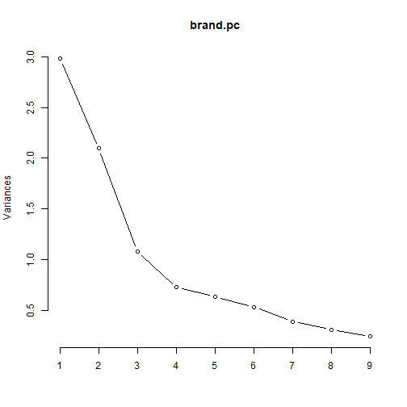

```r
plot(brand.pc, type="l")
```

### Biplot

- A biplot only shows the first two principal components
- Instead of X, Y space, we're using PC1, PC2 space
- Because our first two principal components explained more than 50% of the variance, we feel comfortable using just those two dimensions to explain our data

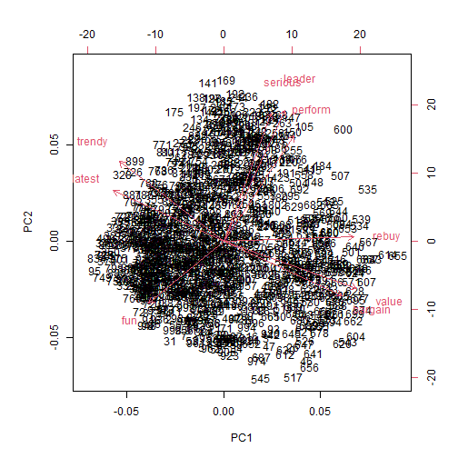

```r
biplot(brand.pc)
```

### Brand Positioning (Step 5)

- The plot of individual respondents' ratings is too dense and it does not tell us about the brand positions.
- A better solution is to perform PCA using aggregated ratings by brand.

```r
brand.mu.pc <- prcomp(brand.mean, scale = TRUE)
summary(brand.mu.pc)
```

```
Importance of components:
                          PC1    PC2    PC3     PC4     PC5
Standard deviation     2.1345 1.7349 0.7690 0.61498 0.50983
Proportion of Variance 0.5062 0.3345 0.0657 0.04202 0.02888
Cumulative Proportion  0.5062 0.8407 0.9064 0.94842 0.97730
                           PC6     PC7     PC8     PC9
Standard deviation     0.36662 0.21506 0.14588 0.04867
Proportion of Variance 0.01493 0.00514 0.00236 0.00026
Cumulative Proportion  0.99223 0.99737 0.99974 1.00000
```

### Perceptual Map (Step 5)

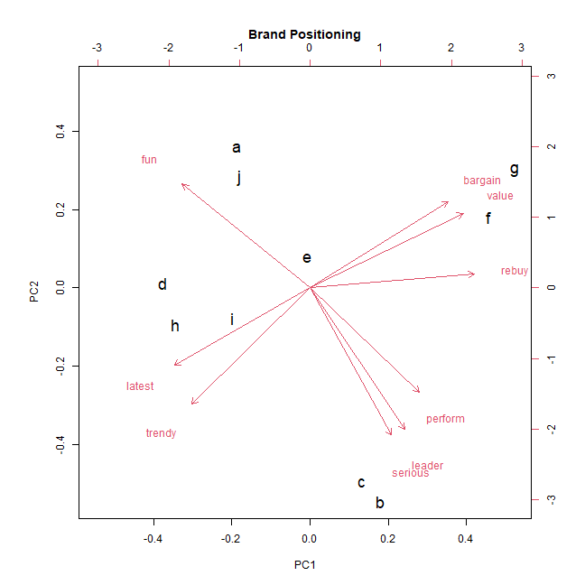

```r
biplot(brand.mu.pc, main = "Brand Positioning", cex=c(1.5,1))
```

### Now what?

### What are possible WaPo use cases?

- Have you used it thus far?